# 4. Analysis of Variance (ANOVA)

Comparing means among treatments

Author

Gustavo Roa

# Analysis of Variance

**Analysis of variance (ANOVA)** is used to compare the means of two or more groups.

In agricultural research, ANOVA is commonly used to evaluate whether treatments produce different responses.

For example:

> **Does grain yield differ among sulfur fertilizer rates?**

In this section, we will use sulfur rate as the treatment and grain yield as the response.

# Why ANOVA?

Treatment means will almost always differ to some degree. The important question is:

> **Are the differences among treatment means large relative to the variation within treatments?**

ANOVA separates total variation into:

- **Between-treatment variation:** variation among treatment means.
- **Within-treatment variation:** variation among observations within treatments.

The basic idea is:

$$F =
\frac{\text{Between-treatment variation}}
{\text{Within-treatment variation}}$$

A large F-statistic indicates that differences among treatment means are large relative to the variation within treatments.

# ANOVA and the t-test

When comparing **two groups**, a two-sample t-test can be used to test whether their means differ.

When comparing **more than two groups**, ANOVA provides an overall test of whether the group means are equal.

| Number of groups | Common approach |
| --- | --- |
| 2 groups | t-test |
| 3 or more groups | ANOVA |

A two-group ANOVA and a two-sample t-test are closely related. Under the same assumptions:

$$F = t^2$$

and they produce the same P-value.

The number of groups is only one consideration. The **experimental design and research question** should determine the statistical model.

# The ANOVA model

A one-way ANOVA can be written as:

$$Y_{ij} = \mu + \tau_i + \varepsilon_{ij}$$

where:

- $Y_{ij}$ is the observed response for observation $j$ in treatment $i$.
- $\mu$ is the overall mean.
- $\tau_i$ is the effect of treatment $i$.
- $\varepsilon_{ij}$ is the random error.

The null hypothesis is:

$$H_0: \mu_1 = \mu_2 = \cdots = \mu_k$$

The alternative hypothesis is:

$$H_A: \text{At least one treatment mean differs}$$

ANOVA tests the overall hypothesis that all treatment means are equal.

> A significant ANOVA does not tell us which treatments differ.

Specific treatment differences require pairwise comparisons or planned contrasts.

# ANOVA assumptions

The main assumptions are:

| Assumption | What to look for |
| --- | --- |
| Independence | Observations are independent. |
| Normality | Model residuals are approximately normal. |
| Constant variance | Residual variability is reasonably similar among treatments. |

For agricultural experiments, the **experimental design** is particularly important when considering independence.

# Load the required packages

We will use:

- `readxl` to import the dataset.
- `ggplot2` to create graphs.
- `emmeans` to estimate treatment means and make comparisons.

```r
# Import Excel files
library(readxl)

# Create graphs
library(ggplot2)

# Estimate treatment means and make comparisons
library(emmeans)
```

# Load the data

We will use the same dataset from the previous sections.

```r
# Import the workshop dataset
AllData <- read_excel(
  "Data_example.xlsx",
  sheet = "data"
)

# Check the structure of the dataset
str(AllData)
```

```
tibble [20 × 11] (S3: tbl_df/tbl/data.frame)
 $ year             : num [1:20] 2022 2022 2022 2022 2022 ...
 $ location         : chr [1:20] "Ashland" "Ashland" "Ashland" "Ashland" ...
 $ block            : num [1:20] 1 1 1 1 1 2 2 2 2 2 ...
 $ S_rate_kg_ha     : num [1:20] 34 11 45 22 0 0 34 22 11 45 ...
 $ grain_yield_Mg_ha: num [1:20] 9.04 10.66 11.25 10.06 7.75 ...
 $ biomass_V6_Mg_ha : num [1:20] 0.39 0.46 0.48 0.38 0.69 0.35 0.49 0.75 0.68 0.59 ...
 $ biomass_R1_Mg_ha : num [1:20] 7.82 8.52 7.6 7.47 10.3 ...
 $ S_conc_V6_pct    : num [1:20] 0.28 0.24 0.29 0.25 0.23 0.25 0.25 0.24 0.24 0.25 ...
 $ N_conc_V6_pct    : num [1:20] 3.86 3.65 3.78 3.67 3.74 3.93 3.8 3.68 3.87 3.66 ...
 $ S_conc_R1_pct    : num [1:20] 0.15 0.13 0.14 0.12 0.13 0.16 0.13 0.13 0.11 0.14 ...
 $ N_conc_R1_pct    : num [1:20] 1.7 1.57 1.7 1.38 1.59 1.81 1.62 1.6 1.41 1.63 ...
```

# Prepare the treatment variable

Sulfur rate is a quantitative variable, but for this one-way ANOVA we treat the tested rates as separate treatment groups.

```r
# Convert sulfur rate to a treatment factor
AllData$S_rate_kg_ha <- factor(AllData$S_rate_kg_ha)
```

# Explore the data

Before fitting an ANOVA model, we can visualize grain yield by sulfur rate.

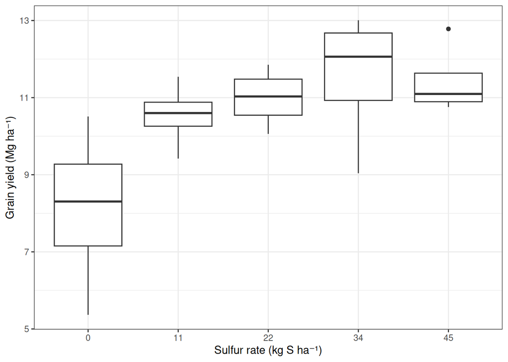

The box plot allows us to compare the distribution and variability of grain yield among treatments.

# Fit the ANOVA model

In R, a one-way ANOVA can be fitted using `aov()`.

```r
# Fit the one-way ANOVA model
model_anova <- aov(
  grain_yield_Mg_ha ~ S_rate_kg_ha,
  data = AllData
)

# Display the ANOVA table
summary(model_anova)
```

```
             Df Sum Sq Mean Sq F value Pr(>F)
S_rate_kg_ha  4  31.41   7.853   3.913 0.0227 *
Residuals    15  30.10   2.007
---
Signif. codes:  0 '***' 0.001 '**' 0.01 '*' 0.05 '.' 0.1 ' ' 1
```

# Understanding the ANOVA table

The ANOVA table separates variation into different sources.

| Output | Meaning |
| --- | --- |
| Df | Degrees of freedom |
| Sum Sq | Sum of squares, a measure of variation |
| Mean Sq | Sum of squares divided by degrees of freedom |
| F value | Ratio of between-treatment to within-treatment variation |
| Pr(>F) | P-value for the overall treatment test |

The main result is the **P-value for the treatment effect**.

A small P-value provides evidence that the treatment means are not all equal.

However, ANOVA does not tell us which treatments differ.

# Post-hoc comparisons

When the overall ANOVA indicates differences among treatments, we may want to compare individual treatment means.

Different methods answer different questions.

## Tukey’s test

**Tukey’s test** is commonly used when we want to compare **all pairs of treatment means**.

For example:

- 0 vs 11 kg S ha⁻¹
- 0 vs 22 kg S ha⁻¹
- 0 vs 34 kg S ha⁻¹
- 0 vs 45 kg S ha⁻¹
- and all other treatment pairs

Tukey’s method adjusts for the multiple comparisons being made.

```r
# Estimate treatment means
emm <- emmeans(
  model_anova,
  ~ S_rate_kg_ha
)

# Compare all treatment pairs using Tukey adjustment
pairs(
  emm,
  adjust = "tukey"
)
```

```
 contrast                        estimate SE df t.ratio p.value
 S_rate_kg_ha0 - S_rate_kg_ha11    -2.418  1 15  -2.414  0.1650
 S_rate_kg_ha0 - S_rate_kg_ha22    -2.871  1 15  -2.866  0.0752
 S_rate_kg_ha0 - S_rate_kg_ha34    -3.420  1 15  -3.415  0.0270
 S_rate_kg_ha0 - S_rate_kg_ha45    -3.311  1 15  -3.305  0.0332
 S_rate_kg_ha11 - S_rate_kg_ha22   -0.453  1 15  -0.453  0.9904
 S_rate_kg_ha11 - S_rate_kg_ha34   -1.003  1 15  -1.001  0.8509
 S_rate_kg_ha11 - S_rate_kg_ha45   -0.893  1 15  -0.891  0.8957
 S_rate_kg_ha22 - S_rate_kg_ha34   -0.549  1 15  -0.548  0.9805
 S_rate_kg_ha22 - S_rate_kg_ha45   -0.440  1 15  -0.439  0.9915
 S_rate_kg_ha34 - S_rate_kg_ha45    0.110  1 15   0.110  1.0000

P value adjustment: tukey method for comparing a family of 5 estimates
```

## Dunnett’s test

**Dunnett’s test** is useful when several treatments are compared with a **single control**.

For example, if 0 kg S ha⁻¹ is the control, we could compare every sulfur treatment with the control.

```r
# Compare each treatment with the control
contrast(
  emm,
  method = "trt.vs.ctrl",
  ref = 1,
  adjust = "dunnett"
)
```

```
 contrast                       estimate SE df t.ratio p.value
 S_rate_kg_ha11 - S_rate_kg_ha0     2.42  1 15   2.414  0.0934
 S_rate_kg_ha22 - S_rate_kg_ha0     2.87  1 15   2.866  0.0398
 S_rate_kg_ha34 - S_rate_kg_ha0     3.42  1 15   3.415  0.0135
 S_rate_kg_ha45 - S_rate_kg_ha0     3.31  1 15   3.305  0.0168

P value adjustment: dunnettx method for 4 tests
```

Here, `ref = 1` indicates that the first treatment level is the control.

## Fisher’s LSD

**Fisher’s least significant difference (LSD)** can be used for pairwise comparisons after an ANOVA.

It is less conservative than Tukey’s test and therefore provides less protection against false positive findings when many comparisons are made.

Fisher’s LSD should be used with an appropriate comparison plan rather than automatically applied to every pair.

## Other methods

Other approaches include:

- **Bonferroni:** adjusts for multiple comparisons.
- **Holm:** a stepwise adjustment for multiple comparisons.
- **Scheffé:** useful for a broad range of planned comparisons and contrasts.

The choice should depend on the **research question and comparison structure**.

# Choosing a post-hoc method

| Method | Main purpose |
| --- | --- |
| **Tukey** | Compare all pairs of means |
| **Dunnett** | Compare treatments with a control |
| **Fisher’s LSD** | Pairwise comparisons with less conservative adjustment |
| **Bonferroni** | Adjust for multiple comparisons |
| **Holm** | Stepwise adjustment for multiple comparisons |
| **Scheffé** | Flexible comparisons and contrasts |

The important question is:

> **Which comparisons are scientifically important?**

A post-hoc method should be selected based on the research question rather than simply choosing a method after looking at the results.

# Exercise

## Exercise 4.1: Fit the ANOVA

Fit a one-way ANOVA using:

- `grain_yield_Mg_ha` as the response.
- `S_rate_kg_ha` as the treatment.

```r
# Fit the one-way ANOVA
model_ex <- aov(
  ____________ ~ ____________,
  data = AllData
)

summary(model_ex)
```

**TipShow solution**

```r
# Fit the one-way ANOVA
model_ex <- aov(
  grain_yield_Mg_ha ~ S_rate_kg_ha,
  data = AllData
)

summary(model_ex)
```

```
             Df Sum Sq Mean Sq F value Pr(>F)
S_rate_kg_ha  4  31.41   7.853   3.913 0.0227 *
Residuals    15  30.10   2.007
---
Signif. codes:  0 '***' 0.001 '**' 0.01 '*' 0.05 '.' 0.1 ' ' 1
```

## Exercise 4.2: Compare treatment means

Use Tukey’s method to compare all pairs of sulfur treatments.

```r
# Estimate treatment means
emm_ex <- emmeans(
  model_ex,
  ~ ____________
)

# Compare all treatment pairs
pairs(
  emm_ex,
  adjust = "tukey"
)
```

**TipShow solution**

```r
# Estimate treatment means
emm_ex <- emmeans(
  model_ex,
  ~ S_rate_kg_ha
)

# Compare all treatment pairs using Tukey adjustment
pairs(
  emm_ex,
  adjust = "tukey"
)
```

```
 contrast                        estimate SE df t.ratio p.value
 S_rate_kg_ha0 - S_rate_kg_ha11    -2.418  1 15  -2.414  0.1650
 S_rate_kg_ha0 - S_rate_kg_ha22    -2.871  1 15  -2.866  0.0752
 S_rate_kg_ha0 - S_rate_kg_ha34    -3.420  1 15  -3.415  0.0270
 S_rate_kg_ha0 - S_rate_kg_ha45    -3.311  1 15  -3.305  0.0332
 S_rate_kg_ha11 - S_rate_kg_ha22   -0.453  1 15  -0.453  0.9904
 S_rate_kg_ha11 - S_rate_kg_ha34   -1.003  1 15  -1.001  0.8509
 S_rate_kg_ha11 - S_rate_kg_ha45   -0.893  1 15  -0.891  0.8957
 S_rate_kg_ha22 - S_rate_kg_ha34   -0.549  1 15  -0.548  0.9805
 S_rate_kg_ha22 - S_rate_kg_ha45   -0.440  1 15  -0.439  0.9915
 S_rate_kg_ha34 - S_rate_kg_ha45    0.110  1 15   0.110  1.0000

P value adjustment: tukey method for comparing a family of 5 estimates
```

## Exercise 4.3: Interpret the results

Use the ANOVA table, post-hoc comparisons, and graph to answer:

1. Is there evidence that grain yield differs among sulfur rates?
2. What is the ANOVA P-value?
3. Which treatment pairs differ according to Tukey’s test?
4. Which sulfur rate has the highest estimated mean yield?

> **Important:** A significant ANOVA tells us that not all treatment means are equal. Post-hoc comparisons help identify which treatments differ.

# Key takeaways

- ANOVA compares means among multiple groups.
- ANOVA separates between-treatment and within-treatment variation.
- The F-statistic compares these two sources of variation.
- A t-test is commonly used when comparing two groups.
- ANOVA is commonly used when comparing more than two groups.
- A significant ANOVA does not identify which treatments differ.
- Post-hoc methods should be selected based on the research question.
- Tukey is useful for all pairwise comparisons.
- Dunnett is useful when comparing treatments with a control.
- Fisher’s LSD is less conservative and should be used with an appropriate comparison plan.

> **The statistical method should follow the research question and experimental design.**

# Next section

In the next section, we will extend the ANOVA framework to linear mixed-effects models, which allow us to account for sources of variation such as blocks, locations, or years in agricultural experiments.